# Supervised Learning - Foundations Project: ReCell

## Problem Statement

### Business Context

Buying and selling used phones and tablets used to be something that happened on a handful of online marketplace sites. But the used and refurbished device market has grown considerably over the past decade, and a new IDC (International Data Corporation) forecast predicts that the used phone market would be worth \$52.7bn by 2023 with a compound annual growth rate (CAGR) of 13.6% from 2018 to 2023. This growth can be attributed to an uptick in demand for used phones and tablets that offer considerable savings compared with new models.

Refurbished and used devices continue to provide cost-effective alternatives to both consumers and businesses that are looking to save money when purchasing one. There are plenty of other benefits associated with the used device market. Used and refurbished devices can be sold with warranties and can also be insured with proof of purchase. Third-party vendors/platforms, such as Verizon, Amazon, etc., provide attractive offers to customers for refurbished devices. Maximizing the longevity of devices through second-hand trade also reduces their environmental impact and helps in recycling and reducing waste. The impact of the COVID-19 outbreak may further boost this segment as consumers cut back on discretionary spending and buy phones and tablets only for immediate needs.

### Objective

The rising potential of this comparatively under-the-radar market fuels the need for an ML-based solution to develop a dynamic pricing strategy for used and refurbished devices. ReCell, a startup aiming to tap the potential in this market, has hired you as a data scientist. They want you to analyze the data provided and build a linear regression model to predict the price of a used phone/tablet and identify factors that significantly influence it.

### Data Description

The data contains the different attributes of used/refurbished phones and tablets. The data was collected in the year 2021. The detailed data dictionary is given below.

- brand_name: Name of manufacturing brand
- os: OS on which the device runs
- screen_size: Size of the screen in cm
- 4g: Whether 4G is available or not
- 5g: Whether 5G is available or not
- main_camera_mp: Resolution of the rear camera in megapixels
- selfie_camera_mp: Resolution of the front camera in megapixels
- int_memory: Amount of internal memory (ROM) in GB
- ram: Amount of RAM in GB
- battery: Energy capacity of the device battery in mAh
- weight: Weight of the device in grams
- release_year: Year when the device model was released
- days_used: Number of days the used/refurbished device has been used
- normalized_new_price: Normalized price of a new device of the same model in euros
- normalized_used_price: Normalized price of the used/refurbished device in euros

## Importing necessary libraries

```python
# Installing the libraries with the specified version.
# uncomment and run the following line if Google Colab is being used
!pip install scikit-learn==1.2.2 seaborn==0.13.1 matplotlib==3.7.1 numpy==1.25.2 pandas==1.5.3 -q --user
```

[output not shown]

```python
# Installing the libraries with the specified version.
# uncomment and run the following lines if Jupyter Notebook is being used
# !pip install scikit-learn==1.2.2 seaborn==0.11.1 matplotlib==3.3.4 numpy==1.24.3 pandas==1.5.2 -q --user
```

**Note**: *After running the above cell, kindly restart the notebook kernel and run all cells sequentially from the start again.*

```python
import pandas as pd
import numpy as np

import matplotlib.pyplot as plt
import seaborn as sns

from sklearn.linear_model import LinearRegression
from sklearn.metrics import mean_absolute_error, mean_squared_error, r2_score

import statsmodels.api as sm
from statsmodels.stats.outliers_influence import variance_inflation_factor
```

## Loading the dataset

```python
data = pd.read_csv('/content/sample_data/used_device_data.csv')
```

## Data Overview

- Observations
- Sanity checks

Displaying the first few rows of the dataset

```python
data.head()
```

|  | brand_name | os | screen_size | 4g | 5g | main_camera_mp | selfie_camera_mp | int_memory | ram | battery | weight | release_year | days_used | normalized_used_price | normalized_new_price |
| --- | --- | --- | --- | --- | --- | --- | --- | --- | --- | --- | --- | --- | --- | --- | --- |
| 0 | Honor | Android | 14.50 | yes | no | 13.0 | 5.0 | 64.0 | 3.0 | 3020.0 | 146.0 | 2020 | 127 | 4.307572 | 4.715100 |
| 1 | Honor | Android | 17.30 | yes | yes | 13.0 | 16.0 | 128.0 | 8.0 | 4300.0 | 213.0 | 2020 | 325 | 5.162097 | 5.519018 |
| 2 | Honor | Android | 16.69 | yes | yes | 13.0 | 8.0 | 128.0 | 8.0 | 4200.0 | 213.0 | 2020 | 162 | 5.111084 | 5.884631 |
| 3 | Honor | Android | 25.50 | yes | yes | 13.0 | 8.0 | 64.0 | 6.0 | 7250.0 | 480.0 | 2020 | 345 | 5.135387 | 5.630961 |
| 4 | Honor | Android | 15.32 | yes | no | 13.0 | 8.0 | 64.0 | 3.0 | 5000.0 | 185.0 | 2020 | 293 | 4.389995 | 4.947837 |

Checking the shape of the dataset

```python
data.shape
```

```
(3454, 15)
```

Checking the data types of the columsn for the dataset

```python
data.info()
```

```
<class 'pandas.core.frame.DataFrame'>
RangeIndex: 3454 entries, 0 to 3453
Data columns (total 15 columns):
 #   Column                 Non-Null Count  Dtype
---  ------                 --------------  -----
 0   brand_name             3454 non-null   object
 1   os                     3454 non-null   object
 2   screen_size            3454 non-null   float64
 3   4g                     3454 non-null   object
 4   5g                     3454 non-null   object
 5   main_camera_mp         3275 non-null   float64
 6   selfie_camera_mp       3452 non-null   float64
 7   int_memory             3450 non-null   float64
 8   ram                    3450 non-null   float64
 9   battery                3448 non-null   float64
 10  weight                 3447 non-null   float64
 11  release_year           3454 non-null   int64
 12  days_used              3454 non-null   int64
 13  normalized_used_price  3454 non-null   float64
 14  normalized_new_price   3454 non-null   float64
dtypes: float64(9), int64(2), object(4)
memory usage: 404.9+ KB
```

Statistical summary of the dataset

```python
data.describe()
```

|  | screen_size | main_camera_mp | selfie_camera_mp | int_memory | ram | battery | weight | release_year | days_used | normalized_used_price | normalized_new_price |
| --- | --- | --- | --- | --- | --- | --- | --- | --- | --- | --- | --- |
| count | 3454.000000 | 3275.000000 | 3452.000000 | 3450.000000 | 3450.000000 | 3448.000000 | 3447.000000 | 3454.000000 | 3454.000000 | 3454.000000 | 3454.000000 |
| mean | 13.713115 | 9.460208 | 6.554229 | 54.573099 | 4.036122 | 3133.402697 | 182.751871 | 2015.965258 | 674.869716 | 4.364712 | 5.233107 |
| std | 3.805280 | 4.815461 | 6.970372 | 84.972371 | 1.365105 | 1299.682844 | 88.413228 | 2.298455 | 248.580166 | 0.588914 | 0.683637 |
| min | 5.080000 | 0.080000 | 0.000000 | 0.010000 | 0.020000 | 500.000000 | 69.000000 | 2013.000000 | 91.000000 | 1.536867 | 2.901422 |
| 25% | 12.700000 | 5.000000 | 2.000000 | 16.000000 | 4.000000 | 2100.000000 | 142.000000 | 2014.000000 | 533.500000 | 4.033931 | 4.790342 |
| 50% | 12.830000 | 8.000000 | 5.000000 | 32.000000 | 4.000000 | 3000.000000 | 160.000000 | 2015.500000 | 690.500000 | 4.405133 | 5.245892 |
| 75% | 15.340000 | 13.000000 | 8.000000 | 64.000000 | 4.000000 | 4000.000000 | 185.000000 | 2018.000000 | 868.750000 | 4.755700 | 5.673718 |
| max | 30.710000 | 48.000000 | 32.000000 | 1024.000000 | 12.000000 | 9720.000000 | 855.000000 | 2020.000000 | 1094.000000 | 6.619433 | 7.847841 |

Checking for duplicate values

```python
data.duplicated().sum()
```

```
np.int64(0)
```

Checking for missing values

```python
data.isnull().sum()
```

|  | 0 |
| --- | --- |
| brand_name | 0 |
| os | 0 |
| screen_size | 0 |
| 4g | 0 |
| 5g | 0 |
| main_camera_mp | 179 |
| selfie_camera_mp | 2 |
| int_memory | 4 |
| ram | 4 |
| battery | 6 |
| weight | 7 |
| release_year | 0 |
| days_used | 0 |
| normalized_used_price | 0 |
| normalized_new_price | 0 |

**dtype:** int64

```python
df = data.copy()
```

## Exploratory Data Analysis (EDA)

- EDA is an important part of any project involving data.
- It is important to investigate and understand the data better before building a model with it.
- A few questions have been mentioned below which will help you approach the analysis in the right manner and generate insights from the data.
- A thorough analysis of the data, in addition to the questions mentioned below, should be done.

**Questions**:

1. What does the distribution of normalized used device prices look like?
2. What percentage of the used device market is dominated by Android devices?
3. The amount of RAM is important for the smooth functioning of a device. How does the amount of RAM vary with the brand?
4. A large battery often increases a device's weight, making it feel uncomfortable in the hands. How does the weight vary for phones and tablets offering large batteries (more than 4500 mAh)?
5. Bigger screens are desirable for entertainment purposes as they offer a better viewing experience. How many phones and tablets are available across different brands with a screen size larger than 6 inches?
6. A lot of devices nowadays offer great selfie cameras, allowing us to capture our favorite moments with loved ones. What is the distribution of devices offering greater than 8MP selfie cameras across brands?
7. Which attributes are highly correlated with the normalized price of a used device?

# Univariate Analysis

```python
# function to plot a boxplot and a histogram along the same scale.


def histogram_boxplot(data, feature, figsize=(15, 10), kde=False, bins=None):
    """
    Boxplot and histogram combined

    data: dataframe
    feature: dataframe column
    figsize: size of figure (default (15,10))
    kde: whether to show the density curve (default False)
    bins: number of bins for histogram (default None)
    """
    f2, (ax_box2, ax_hist2) = plt.subplots(
        nrows=2,  # Number of rows of the subplot grid= 2
        sharex=True,  # x-axis will be shared among all subplots
        gridspec_kw={"height_ratios": (0.25, 0.75)},
        figsize=figsize,
    )  # creating the 2 subplots
    sns.boxplot(
        data=data, x=feature, ax=ax_box2, showmeans=True, color="violet"
    )  # boxplot will be created and a triangle will indicate the mean value of the column
    sns.histplot(
        data=data, x=feature, kde=kde, ax=ax_hist2, bins=bins
    ) if bins else sns.histplot(
        data=data, x=feature, kde=kde, ax=ax_hist2
    )  # For histogram
    ax_hist2.axvline(
        data[feature].mean(), color="green", linestyle="--"
    )  # Add mean to the histogram
    ax_hist2.axvline(
        data[feature].median(), color="black", linestyle="-"
    )  # Add median to the histogram
```

```python
# function to create labeled barplots


def labeled_barplot(data, feature, perc=False, n=None):
    """
    Barplot with percentage at the top

    data: dataframe
    feature: dataframe column
    perc: whether to display percentages instead of count (default is False)
    n: displays the top n category levels (default is None, i.e., display all levels)
    """

    total = len(data[feature])  # length of the column
    count = data[feature].nunique()
    if n is None:
        plt.figure(figsize=(count + 2, 6))
    else:
        plt.figure(figsize=(n + 2, 6))

    plt.xticks(rotation=90, fontsize=15)
    ax = sns.countplot(
        data=data,
        x=feature,
        order=data[feature].value_counts().index[:n],
    )

    for p in ax.patches:
        if perc == True:
            label = "{:.1f}%".format(
                100 * p.get_height() / total
            )  # percentage of each class of the category
        else:
            label = p.get_height()  # count of each level of the category

        x = p.get_x() + p.get_width() / 2  # width of the plot
        y = p.get_height()  # height of the plot

        ax.annotate(
            label,
            (x, y),
            ha="center",
            va="center",
            size=12,
            xytext=(0, 5),
            textcoords="offset points",
        )  # annotate the percentage

    plt.show()  # show the plot
```

normalized_used_price

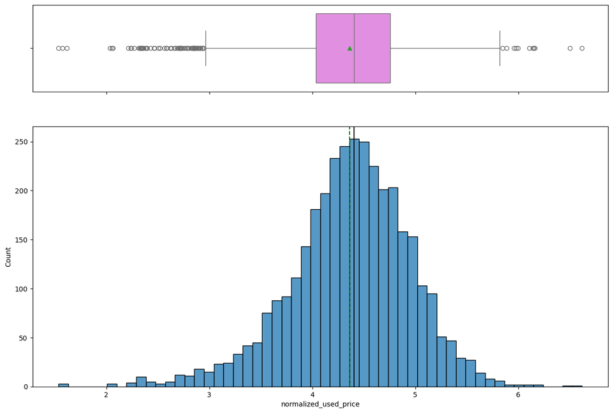

```python
histogram_boxplot(df, "normalized_used_price")
```

normalized_new_price

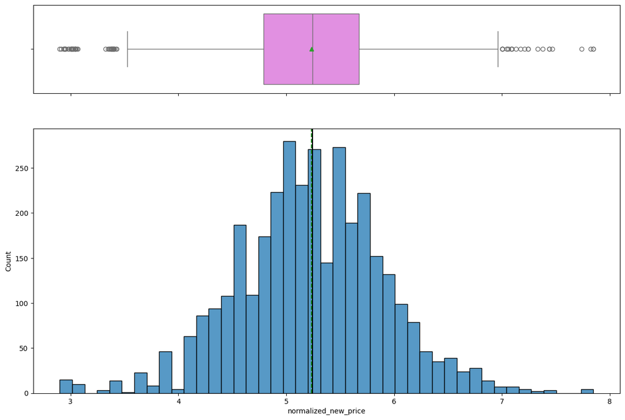

```python
histogram_boxplot(df, "normalized_new_price")
```

screen_size

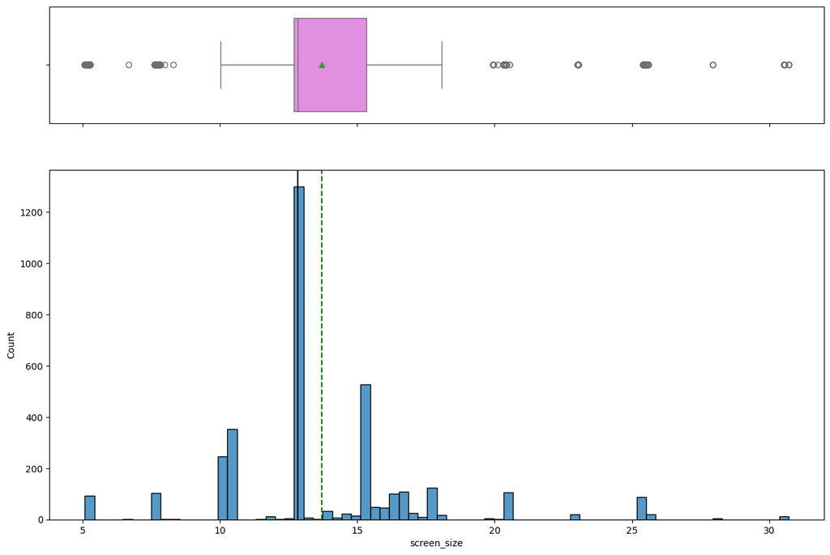

```python
histogram_boxplot(df, "screen_size")
```

main_camera_mp

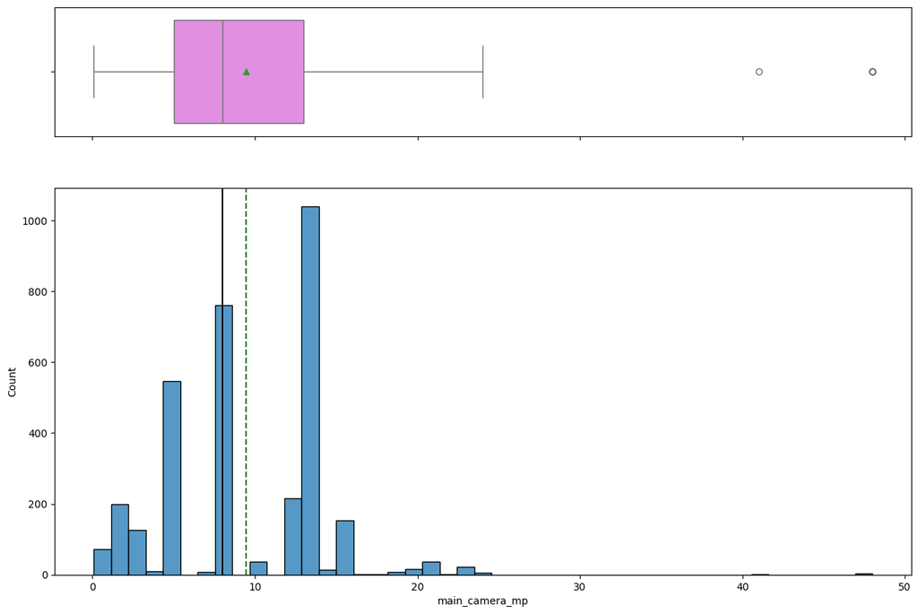

```python
histogram_boxplot(df, "main_camera_mp")
```

selfie_camera_mp

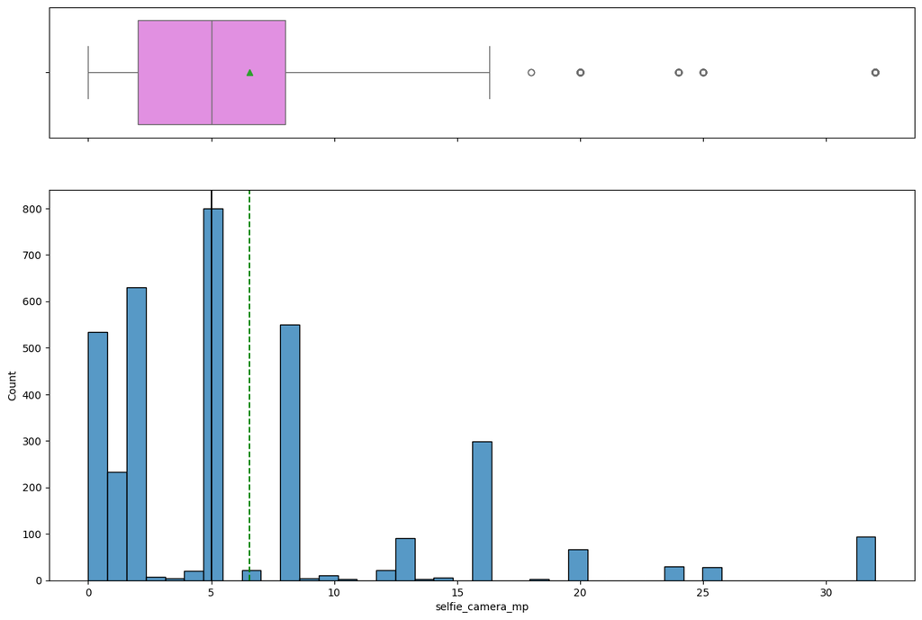

```python
histogram_boxplot(df, "selfie_camera_mp")
```

int_memory

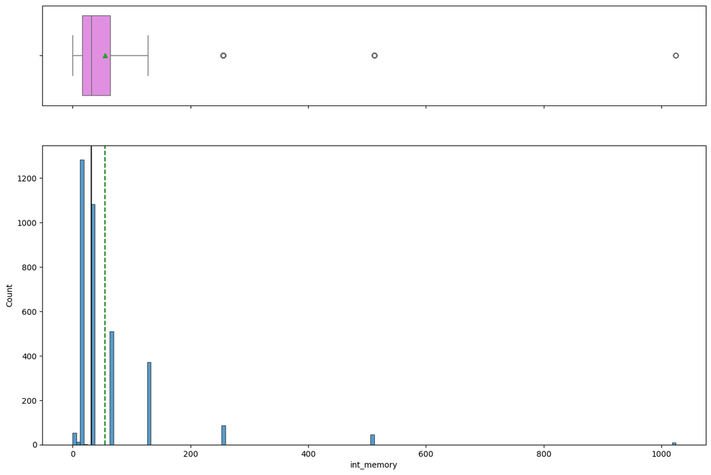

```python
histogram_boxplot(df, "int_memory")
```

ram

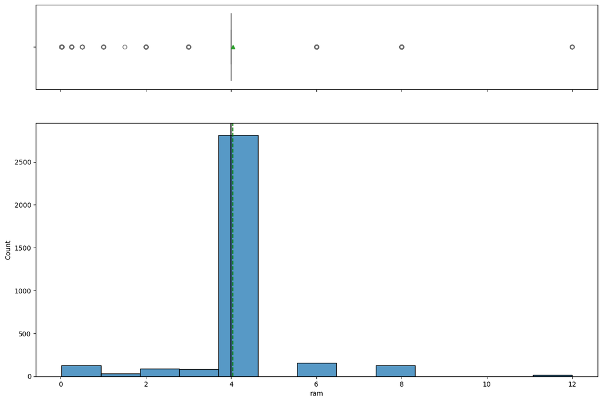

```python
histogram_boxplot(df, "ram")
```

weight

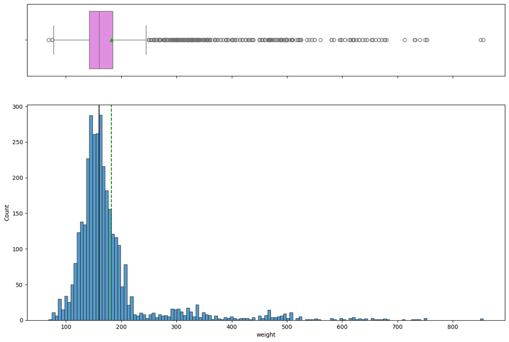

```python
histogram_boxplot(df, "weight")
```

battery

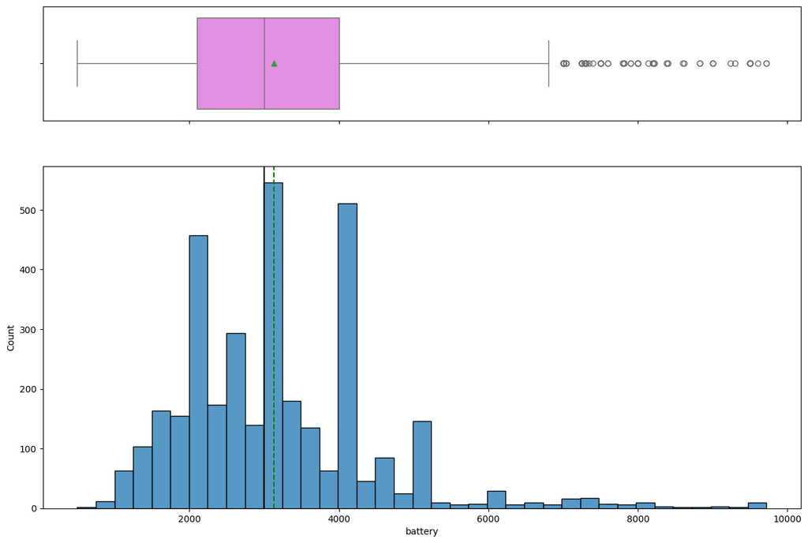

```python
histogram_boxplot(df, "battery")
```

days_used

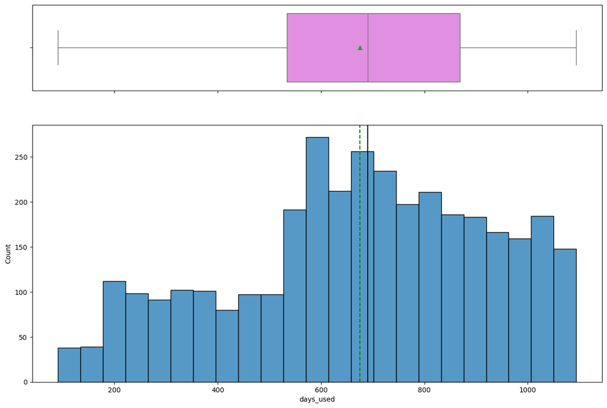

```python
histogram_boxplot(df, "days_used")
```

brand_name

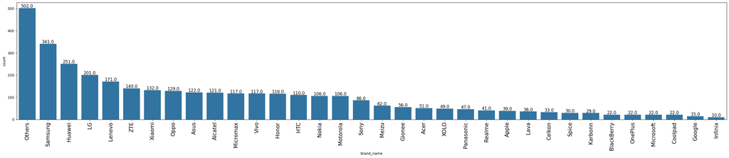

```python
labeled_barplot(df, "brand_name")
```

os

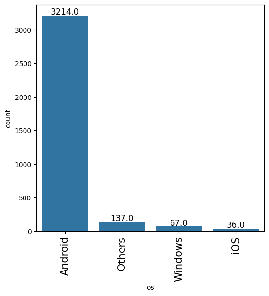

```python
labeled_barplot(df, "os")
```

4g

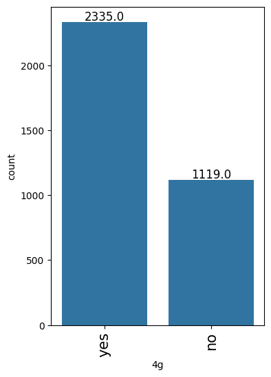

```python
labeled_barplot(df,"4g")
```

5g

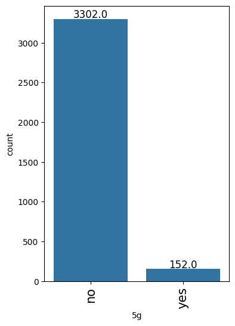

```python
labeled_barplot(df,"5g")
```

release_year

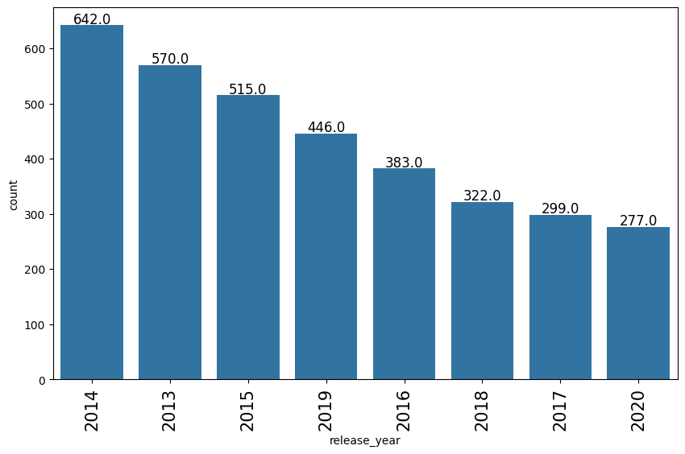

```python
labeled_barplot(df,"release_year")
```

# Bivariate Analysis

Correlation check

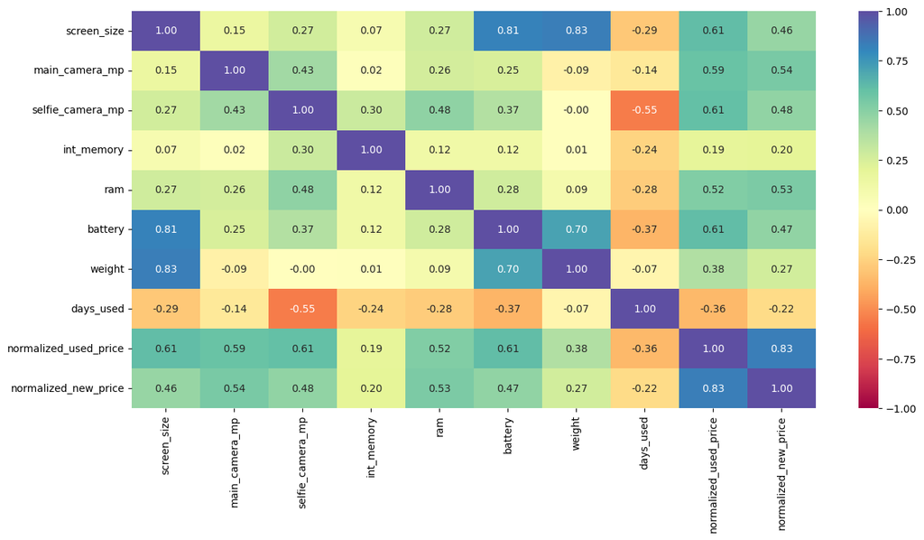

```python
cols_list = df.select_dtypes(include=np.number).columns.tolist()
# dropping release_year as it is a temporal variable
cols_list.remove("release_year")

plt.figure(figsize=(15, 7))
sns.heatmap(
    df[cols_list].corr(), annot=True, vmin=-1, vmax=1, fmt=".2f", cmap="Spectral"
)
plt.show()
```

The amount of RAM is important for the smooth functioning of a device. Let's see how the amount of RAM varies across brands.

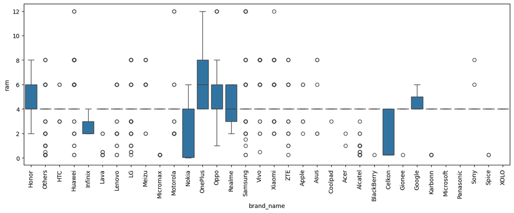

```python
plt.figure(figsize=(15, 5))
sns.boxplot(data=df, x="brand_name", y="ram")
plt.xticks(rotation=90)
plt.show()
```

People who travel frequently require devices with large batteries to run through the day. But large battery often increases weight, making it feel uncomfortable in the hands. Let's create a new dataframe of only those devices which offer a large battery and analyze.

```python
df_large_battery = df[df.battery > 4500]
df_large_battery.shape
```

```
(341, 15)
```

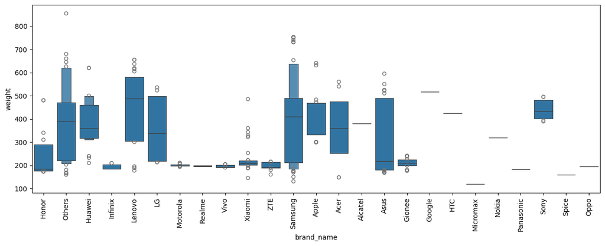

```python
plt.figure(figsize=(15, 5))
sns.boxenplot(data=df_large_battery, x="brand_name", y="weight")
plt.xticks(rotation=90)
plt.show()
```

```python
df_large_screen = df[df.screen_size > 6 * 2.54]
df_large_screen.shape
```

```
(1099, 15)
```

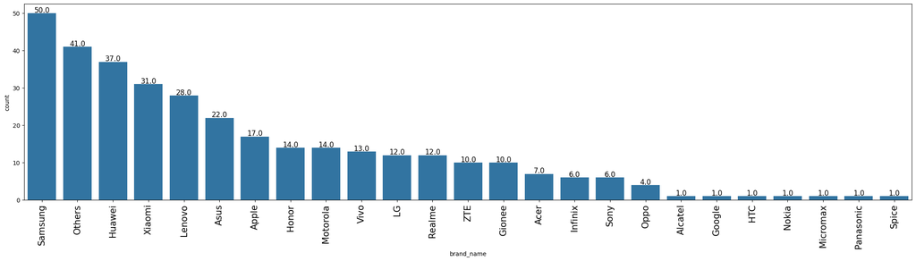

```python
labeled_barplot(df_large_battery, "brand_name")
```

Everyone likes a good camera to capture their favorite moments with loved ones. Some customers specifically look for good front cameras to click cool selfies. Let's create a new dataframe of only those devices which are suitable for this customer segment and analyze.

```python
df_selfie_camera = df[df.selfie_camera_mp > 8]
df_selfie_camera.shape
```

```
(655, 15)
```

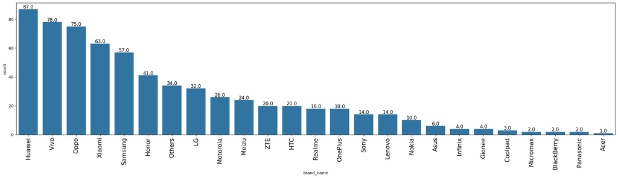

```python
labeled_barplot(df_selfie_camera, "brand_name")
```

Let's do a similar analysis for rear cameras.

Rear cameras generally have a better resolution than front cameras, so we set the threshold higher for them at 16MP.

```python
df_main_camera = df[df.main_camera_mp > 16]
df_main_camera.shape
```

```
(94, 15)
```

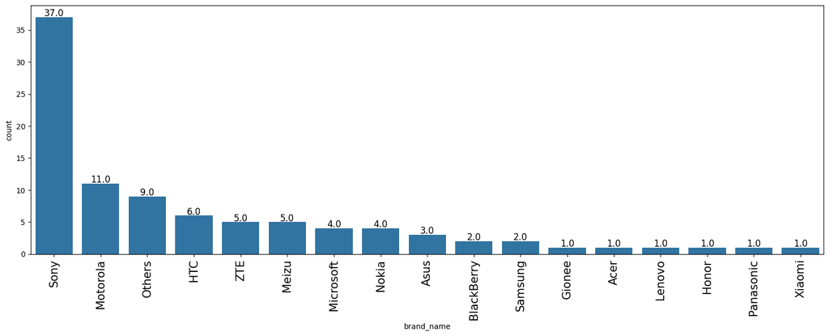

```python
labeled_barplot(df_main_camera, "brand_name")
```

Let's see how the price of used devices varies across the years.

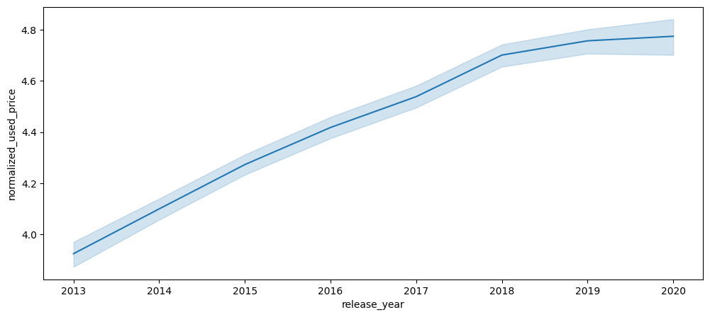

```python
plt.figure(figsize=(12, 5))
sns.lineplot(data=df, x="release_year", y="normalized_used_price")
plt.show()
```

Let's check how the prices vary for used phones and tablets offering 4G and 5G networks.

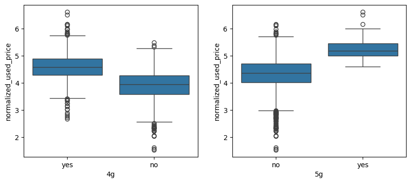

```python
plt.figure(figsize=(10, 4))

plt.subplot(121)
sns.boxplot(data=df, x="4g", y="normalized_used_price")

plt.subplot(122)
sns.boxplot(data=df, x="5g", y="normalized_used_price")

plt.show()
```

# Questions

```python
android_share = df['os'].value_counts(normalize=True)['Android'] * 100
android_share
```

```
np.float64(93.05153445280834)
```

There is a 93% of Android devices in the data set.

Different brands vary in RAM capacity. Brands likey differ significantly, with some offering higer median RAM.

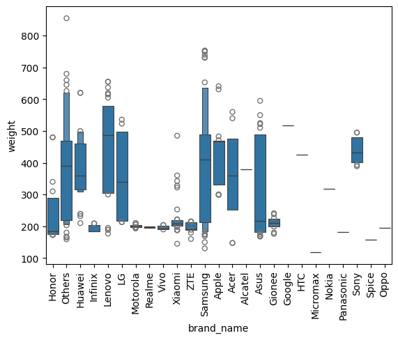

```python
df_large_battery = df[df.battery > 4500]
sns.boxenplot(data=df_large_battery, x="brand_name", y="weight")
figsize=(20,10)
plt.xticks(rotation=90)
plt.show()
```

This visualizes the weight distrribution across brands for devices with large batteries, revealing that some brands produce heavier devices, possibly due to additional features or design.

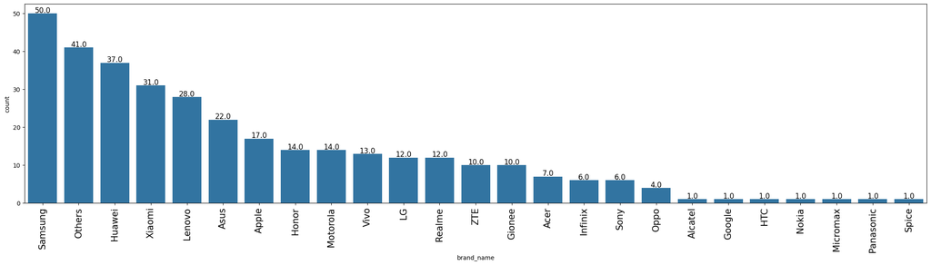

```python
df_large_screen = df[df.screen_size > 6]
labeled_barplot(df_large_battery, "brand_name")
```

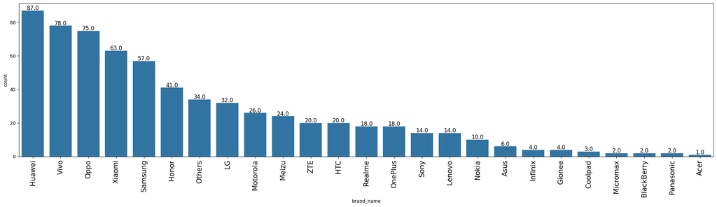

```python
df_selfie_camera = df[df.selfie_camera_mp > 8]
labeled_barplot(df_selfie_camera, "brand_name")
```

This shows that the distribution of devices is right-skewed.

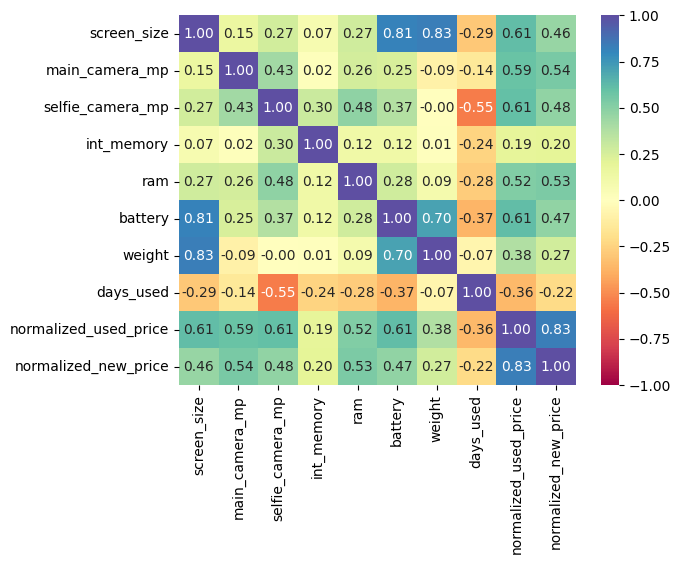

```python
sns.heatmap(df[cols_list].corr(), annot=True, vmin=-1, vmax=1, fmt=".2f", cmap="Spectral")
plt.show()
```

From this we can see that main_camera_mp, scren_size, selfie_camera_mp, battery and normalized_new price are highly correletaed with the normalized price of a used device.

## Data Preprocessing

- Missing value treatment
- Feature engineering (if needed)
- Outlier detection and treatment (if needed)
- Preparing data for modeling
- Any other preprocessing steps (if needed)

Missing Value Imputation

```python
df1 = df.copy()
```

```python
df1.isnull().sum()
```

|  | 0 |
| --- | --- |
| brand_name | 0 |
| os | 0 |
| screen_size | 0 |
| 4g | 0 |
| 5g | 0 |
| main_camera_mp | 179 |
| selfie_camera_mp | 2 |
| int_memory | 4 |
| ram | 4 |
| battery | 6 |
| weight | 7 |
| release_year | 0 |
| days_used | 0 |
| normalized_used_price | 0 |
| normalized_new_price | 0 |

**dtype:** int64

We will impute the missing values in the data by the column medians grouped by release_year and brand_name.

```python
cols_impute = [
    "main_camera_mp",
    "selfie_camera_mp",
    "int_memory",
    "ram",
    "battery",
    "weight",
]

for col in cols_impute:
    df1[col] = df1[col].fillna(
        value=df1.groupby(["brand_name", "release_year"])[col].transform("median")
    )

df1.isnull().sum()
```

|  | 0 |
| --- | --- |
| brand_name | 0 |
| os | 0 |
| screen_size | 0 |
| 4g | 0 |
| 5g | 0 |
| main_camera_mp | 179 |
| selfie_camera_mp | 2 |
| int_memory | 0 |
| ram | 0 |
| battery | 6 |
| weight | 7 |
| release_year | 0 |
| days_used | 0 |
| normalized_used_price | 0 |
| normalized_new_price | 0 |

**dtype:** int64

We will impute the remaining missing values in the data by the column medians grouped by brand_name.

```python
cols_impute = [
    "main_camera_mp",
    "selfie_camera_mp",
    "battery",
    "weight",
]

for col in cols_impute:
    df1[col] = df1[col].fillna(
        value=df1.groupby(['brand_name'])[col].transform("median")
    )
df1.isnull().sum()
```

|  | 0 |
| --- | --- |
| brand_name | 0 |
| os | 0 |
| screen_size | 0 |
| 4g | 0 |
| 5g | 0 |
| main_camera_mp | 10 |
| selfie_camera_mp | 0 |
| int_memory | 0 |
| ram | 0 |
| battery | 0 |
| weight | 0 |
| release_year | 0 |
| days_used | 0 |
| normalized_used_price | 0 |
| normalized_new_price | 0 |

**dtype:** int64

We will fill the remaining missing values in the main_camera_mp column by the column median.

```python
df1["main_camera_mp"] = df1["main_camera_mp"].fillna(df1["main_camera_mp"].median())

df1.isnull().sum()
```

|  | 0 |
| --- | --- |
| brand_name | 0 |
| os | 0 |
| screen_size | 0 |
| 4g | 0 |
| 5g | 0 |
| main_camera_mp | 0 |
| selfie_camera_mp | 0 |
| int_memory | 0 |
| ram | 0 |
| battery | 0 |
| weight | 0 |
| release_year | 0 |
| days_used | 0 |
| normalized_used_price | 0 |
| normalized_new_price | 0 |

**dtype:** int64

Feature engineering

Create a new column years_since_release from the release_year column. We will consider the year of data collection, 2021, as the baseline. We will drop the release_year column

```python
df1["years_since_release"] = 2021 - df1["release_year"]
df1.drop("release_year", axis=1, inplace=True)
df1["years_since_release"].describe()
```

|  | years_since_release |
| --- | --- |
| count | 3454.000000 |
| mean | 5.034742 |
| std | 2.298455 |
| min | 1.000000 |
| 25% | 3.000000 |
| 50% | 5.500000 |
| 75% | 7.000000 |
| max | 8.000000 |

**dtype:** float64

Outlier check

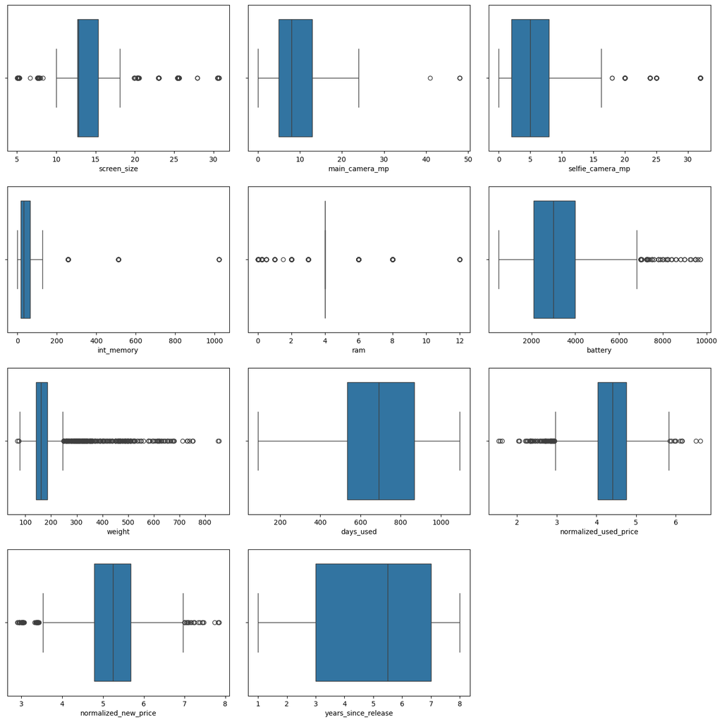

```python
# outlier detection using boxplot
num_cols = df1.select_dtypes(include=np.number).columns.tolist()

plt.figure(figsize=(15, 15))

for i, variable in enumerate(num_cols):
    plt.subplot(4, 3, i + 1)
    sns.boxplot(data=df1, x=variable)
    plt.tight_layout(pad=2)

plt.show()
```

Data Preparation for Modeling

- We want to predict the normalized price of used devices
- Before we proceed to build a model, we'll have to encode categorical features
- We'll split the data into train and test to be able to evaluate the model that we build on the train data
- We will build a Linear Regression model using the train data and then check it's performance

```python
X = df1.drop(columns=["normalized_used_price"])
y = df1["normalized_used_price"]

print(X.head())
print()
print(y.head())

print(X.dtypes)
```

```
  brand_name       os  ...  normalized_new_price years_since_release
0      Honor  Android  ...              4.715100                   1
1      Honor  Android  ...              5.519018                   1
2      Honor  Android  ...              5.884631                   1
3      Honor  Android  ...              5.630961                   1
4      Honor  Android  ...              4.947837                   1

[5 rows x 14 columns]

0    4.307572
1    5.162097
2    5.111084
3    5.135387
4    4.389995
Name: normalized_used_price, dtype: float64
brand_name               object
os                       object
screen_size             float64
4g                       object
5g                       object
main_camera_mp          float64
selfie_camera_mp        float64
int_memory              float64
ram                     float64
battery                 float64
weight                  float64
days_used                 int64
normalized_new_price    float64
years_since_release       int64
dtype: object
```

```python
# let's add the intercept to data
X = sm.add_constant(X)
```

```python
X = pd.get_dummies(
    X,
    columns=X.select_dtypes(include=["object", "category"]).columns.tolist(),
    drop_first=True,
)
X[X.select_dtypes("bool").columns] = X.select_dtypes("bool").astype(int)
```

```python
# splitting the data in 70:30 ratio for train to test data
from sklearn.model_selection import train_test_split
x_train, x_test, y_train, y_test = train_test_split(X, y, test_size=0.3, random_state=42)
```

```python
print("Number of rows in train data =", x_train.shape[0])
print("Number of rows in test data =", x_test.shape[0])
```

```
Number of rows in train data = 2417
Number of rows in test data = 1037
```

## Model Building - Linear Regression

```python
olsmodel1 = sm.OLS(y_train, x_train).fit()
olsmodel1.summary()
```

OLS Regression Results

| Dep. Variable: | normalized_used_price | R-squared: | 0.849 |
| --- | --- | --- | --- |
| Model: | OLS | Adj. R-squared: | 0.846 |
| Method: | Least Squares | F-statistic: | 277.1 |
| Date: | Mon, 05 May 2025 | Prob (F-statistic): | 0.00 |
| Time: | 06:40:07 | Log-Likelihood: | 125.15 |
| No. Observations: | 2417 | AIC: | -152.3 |
| Df Residuals: | 2368 | BIC: | 131.4 |
| Df Model: | 48 |  |  |
| Covariance Type: | nonrobust |  |  |

|  | coef | std err | t | P>\|t\| | [0.025 | 0.975] |
| --- | --- | --- | --- | --- | --- | --- |
| const | 1.4172 | 0.072 | 19.677 | 0.000 | 1.276 | 1.558 |
| screen_size | 0.0295 | 0.004 | 8.352 | 0.000 | 0.023 | 0.036 |
| main_camera_mp | 0.0232 | 0.002 | 14.892 | 0.000 | 0.020 | 0.026 |
| selfie_camera_mp | 0.0116 | 0.001 | 9.924 | 0.000 | 0.009 | 0.014 |
| int_memory | 0.0002 | 6.76e-05 | 2.779 | 0.005 | 5.53e-05 | 0.000 |
| ram | 0.0305 | 0.005 | 5.797 | 0.000 | 0.020 | 0.041 |
| battery | -1.665e-05 | 7.35e-06 | -2.266 | 0.024 | -3.11e-05 | -2.24e-06 |
| weight | 0.0008 | 0.000 | 5.946 | 0.000 | 0.001 | 0.001 |
| days_used | 3.376e-05 | 3.07e-05 | 1.101 | 0.271 | -2.64e-05 | 9.39e-05 |
| normalized_new_price | 0.4104 | 0.012 | 33.494 | 0.000 | 0.386 | 0.434 |
| years_since_release | -0.0255 | 0.005 | -5.589 | 0.000 | -0.034 | -0.017 |
| brand_name_Alcatel | -0.0804 | 0.050 | -1.618 | 0.106 | -0.178 | 0.017 |
| brand_name_Apple | -0.0438 | 0.148 | -0.297 | 0.767 | -0.333 | 0.246 |
| brand_name_Asus | 0.0068 | 0.049 | 0.138 | 0.890 | -0.090 | 0.103 |
| brand_name_BlackBerry | 0.0312 | 0.072 | 0.434 | 0.664 | -0.110 | 0.172 |
| brand_name_Celkon | -0.2372 | 0.068 | -3.485 | 0.001 | -0.371 | -0.104 |
| brand_name_Coolpad | -0.0308 | 0.071 | -0.434 | 0.664 | -0.170 | 0.108 |
| brand_name_Gionee | -0.0130 | 0.059 | -0.221 | 0.825 | -0.128 | 0.102 |
| brand_name_Google | -0.1192 | 0.083 | -1.442 | 0.149 | -0.281 | 0.043 |
| brand_name_HTC | -0.0403 | 0.050 | -0.805 | 0.421 | -0.138 | 0.058 |
| brand_name_Honor | -0.0478 | 0.051 | -0.941 | 0.347 | -0.147 | 0.052 |
| brand_name_Huawei | -0.0599 | 0.046 | -1.299 | 0.194 | -0.150 | 0.030 |
| brand_name_Infinix | 0.1338 | 0.113 | 1.179 | 0.238 | -0.089 | 0.356 |
| brand_name_Karbonn | -0.0592 | 0.068 | -0.867 | 0.386 | -0.193 | 0.075 |
| brand_name_LG | -0.0608 | 0.047 | -1.299 | 0.194 | -0.152 | 0.031 |
| brand_name_Lava | -0.0230 | 0.063 | -0.364 | 0.716 | -0.147 | 0.101 |
| brand_name_Lenovo | -0.0364 | 0.047 | -0.771 | 0.441 | -0.129 | 0.056 |
| brand_name_Meizu | -0.0860 | 0.056 | -1.530 | 0.126 | -0.196 | 0.024 |
| brand_name_Micromax | -0.0645 | 0.049 | -1.315 | 0.189 | -0.161 | 0.032 |
| brand_name_Microsoft | 0.0749 | 0.082 | 0.916 | 0.360 | -0.085 | 0.235 |
| brand_name_Motorola | -0.0686 | 0.051 | -1.349 | 0.177 | -0.168 | 0.031 |
| brand_name_Nokia | 0.0380 | 0.052 | 0.724 | 0.469 | -0.065 | 0.141 |
| brand_name_OnePlus | -0.0384 | 0.073 | -0.523 | 0.601 | -0.182 | 0.105 |
| brand_name_Oppo | -0.0294 | 0.049 | -0.599 | 0.549 | -0.126 | 0.067 |
| brand_name_Others | -0.0679 | 0.044 | -1.556 | 0.120 | -0.154 | 0.018 |
| brand_name_Panasonic | -0.0427 | 0.062 | -0.690 | 0.490 | -0.164 | 0.078 |
| brand_name_Realme | -0.0359 | 0.063 | -0.568 | 0.570 | -0.160 | 0.088 |
| brand_name_Samsung | -0.0617 | 0.045 | -1.376 | 0.169 | -0.150 | 0.026 |
| brand_name_Sony | -0.0756 | 0.053 | -1.428 | 0.153 | -0.179 | 0.028 |
| brand_name_Spice | -0.0356 | 0.068 | -0.520 | 0.603 | -0.170 | 0.099 |
| brand_name_Vivo | -0.0644 | 0.050 | -1.277 | 0.202 | -0.163 | 0.034 |
| brand_name_XOLO | -0.0781 | 0.057 | -1.362 | 0.173 | -0.191 | 0.034 |
| brand_name_Xiaomi | 0.0325 | 0.050 | 0.655 | 0.513 | -0.065 | 0.130 |
| brand_name_ZTE | -0.0460 | 0.048 | -0.952 | 0.341 | -0.141 | 0.049 |
| os_Others | -0.0604 | 0.033 | -1.856 | 0.064 | -0.124 | 0.003 |
| os_Windows | -0.0374 | 0.043 | -0.861 | 0.389 | -0.122 | 0.048 |
| os_iOS | -0.0141 | 0.148 | -0.095 | 0.924 | -0.304 | 0.276 |
| 4g_yes | 0.0406 | 0.016 | 2.514 | 0.012 | 0.009 | 0.072 |
| 5g_yes | -0.0916 | 0.032 | -2.846 | 0.004 | -0.155 | -0.029 |

| Omnibus: | 234.465 | Durbin-Watson: | 1.994 |
| --- | --- | --- | --- |
| Prob(Omnibus): | 0.000 | Jarque-Bera (JB): | 630.705 |
| Skew: | -0.536 | Prob(JB): | 1.11e-137 |
| Kurtosis: | 5.262 | Cond. No. | 1.85e+05 |

Notes:  
[1] Standard Errors assume that the covariance matrix of the errors is correctly specified.  
[2] The condition number is large, 1.85e+05. This might indicate that there are  
strong multicollinearity or other numerical problems.

## Model Performance Check

```python
# function to compute adjusted R-squared
def adj_r2_score(predictors, targets, predictions):
    r2 = r2_score(targets, predictions)
    n = predictors.shape[0]
    k = predictors.shape[1]
    return 1 - ((1 - r2) * (n - 1) / (n - k - 1))


# function to compute MAPE
def mape_score(targets, predictions):
    return np.mean(np.abs(targets - predictions) / targets) * 100


# function to compute different metrics to check performance of a regression model
def model_performance_regression(model, predictors, target):
    """
    Function to compute different metrics to check regression model performance

    model: regressor
    predictors: independent variables
    target: dependent variable
    """

    # predicting using the independent variables
    pred = model.predict(predictors)

    r2 = r2_score(target, pred)  # to compute R-squared
    adjr2 = adj_r2_score(predictors, target, pred)  # to compute adjusted R-squared
    rmse = np.sqrt(mean_squared_error(target, pred))  # to compute RMSE
    mae = mean_absolute_error(target, pred)  # to compute MAE
    mape = mape_score(target, pred)  # to compute MAPE

    # creating a dataframe of metrics
    df_perf = pd.DataFrame(
        {
            "RMSE": rmse,
            "MAE": mae,
            "R-squared": r2,
            "Adj. R-squared": adjr2,
            "MAPE": mape,
        },
        index=[0],
    )

    return df_perf
```

```python
# checking model performance on train set (seen 70% data)
print("Training Performance\n")
olsmodel1_train_perf = model_performance_regression(olsmodel1, x_train, y_train)
olsmodel1_train_perf
```

```
Training Performance
```

|  | RMSE | MAE | R-squared | Adj. R-squared | MAPE |
| --- | --- | --- | --- | --- | --- |
| 0 | 0.229761 | 0.178533 | 0.848887 | 0.845758 | 4.293664 |

```python
# checking model performance on test set (seen 30% data)
print("Test Performance\n")
olsmodel1_test_perf = model_performance_regression(olsmodel1, x_test, y_test)
olsmodel1_test_perf
```

```
Test Performance
```

|  | RMSE | MAE | R-squared | Adj. R-squared | MAPE |
| --- | --- | --- | --- | --- | --- |
| 0 | 0.239062 | 0.188692 | 0.832176 | 0.823844 | 4.513288 |

## Checking Linear Regression Assumptions

- In order to make statistical inferences from a linear regression model, it is important to ensure that the assumptions of linear regression are satisfied.

Test for multicollinearity

```python
#Let's define a function to check VIF.

def checking_vif(predictors):
    vif = pd.DataFrame()
    vif["feature"] = predictors.columns

    # calculating VIF for each feature
    vif["VIF"] = [
        variance_inflation_factor(predictors.values, i)
        for i in range(len(predictors.columns))
    ]
    return vif
```

```python
vif = checking_vif(x_train)
```

Removing Multicollinearity

```python
def treating_multicollinearity(predictors, target, high_vif_columns):
    """
    Checking the effect of dropping the columns showing high multicollinearity
    on model performance (adj. R-squared and RMSE)

    predictors: independent variables
    target: dependent variable
    high_vif_columns: columns having high VIF
    """
    # empty lists to store adj. R-squared and RMSE values
    adj_r2 = []
    rmse = []

    # build ols models by dropping one of the high VIF columns at a time
    # store the adjusted R-squared and RMSE in the lists defined previously
    for cols in high_vif_columns:
        # defining the new train set
        train = predictors.loc[:, ~predictors.columns.str.startswith(cols)]

        # create the model
        olsmodel = sm.OLS(target, train).fit()

        # adding adj. R-squared and RMSE to the lists
        adj_r2.append(olsmodel.rsquared_adj)
        rmse.append(np.sqrt(olsmodel.mse_resid))

    # creating a dataframe for the results
    temp = pd.DataFrame(
        {
            "col": high_vif_columns,
            "Adj. R-squared after_dropping col": adj_r2,
            "RMSE after dropping col": rmse,
        }
    ).sort_values(by="Adj. R-squared after_dropping col", ascending=False)
    temp.reset_index(drop=True, inplace=True)

    return temp
```

```python
col_list = vif.loc[vif["VIF"] > 5, "feature"]
res = treating_multicollinearity(x_train, y_train, col_list)
res
```

|  | col | Adj. R-squared after_dropping col | RMSE after dropping col |
| --- | --- | --- | --- |
| 0 | const | 0.996765 | 0.250332 |
| 1 | os_iOS | 0.845888 | 0.232077 |
| 2 | brand_name_Apple | 0.845883 | 0.232081 |
| 3 | brand_name_Huawei | 0.845779 | 0.232159 |
| 4 | brand_name_LG | 0.845779 | 0.232159 |
| 5 | brand_name_Samsung | 0.845765 | 0.232169 |
| 6 | brand_name_Others | 0.845731 | 0.232195 |
| 7 | weight | 0.843587 | 0.233803 |
| 8 | screen_size | 0.841348 | 0.235470 |

```python
col_to_drop = 'const'
x_train2 = x_train.loc[:, ~x_train.columns.str.startswith(col_to_drop)]
x_test2 = x_test.loc[:, ~x_test.columns.str.startswith(col_to_drop)]

# Check VIF now
vif = checking_vif(x_train2)
print("VIF after dropping ", col_to_drop)
vif
```

```
VIF after dropping  const
```

|  | feature | VIF |
| --- | --- | --- |
| 0 | screen_size | 102.190595 |
| 1 | main_camera_mp | 12.248274 |
| 2 | selfie_camera_mp | 5.491430 |
| 3 | int_memory | 1.960277 |
| 4 | ram | 22.297852 |
| 5 | battery | 27.779144 |
| 6 | weight | 30.936145 |
| 7 | days_used | 21.432972 |
| 8 | normalized_new_price | 140.127627 |
| 9 | years_since_release | 27.772725 |
| 10 | brand_name_Alcatel | 2.589890 |
| 11 | brand_name_Apple | 11.297016 |
| 12 | brand_name_Asus | 2.898912 |
| 13 | brand_name_BlackBerry | 1.493597 |
| 14 | brand_name_Celkon | 1.499454 |
| 15 | brand_name_Coolpad | 1.372208 |
| 16 | brand_name_Gionee | 1.746642 |
| 17 | brand_name_Google | 1.294055 |
| 18 | brand_name_HTC | 2.778331 |
| 19 | brand_name_Honor | 2.688489 |
| 20 | brand_name_Huawei | 4.955117 |
| 21 | brand_name_Infinix | 1.096743 |
| 22 | brand_name_Karbonn | 1.384946 |
| 23 | brand_name_LG | 4.073584 |
| 24 | brand_name_Lava | 1.475117 |
| 25 | brand_name_Lenovo | 3.482675 |
| 26 | brand_name_Meizu | 1.936412 |
| 27 | brand_name_Micromax | 2.661684 |
| 28 | brand_name_Microsoft | 1.870974 |
| 29 | brand_name_Motorola | 2.482166 |
| 30 | brand_name_Nokia | 2.778560 |
| 31 | brand_name_OnePlus | 1.461936 |
| 32 | brand_name_Oppo | 3.388119 |
| 33 | brand_name_Others | 8.265907 |
| 34 | brand_name_Panasonic | 1.549671 |
| 35 | brand_name_Realme | 1.526310 |
| 36 | brand_name_Samsung | 6.548418 |
| 37 | brand_name_Sony | 2.333594 |
| 38 | brand_name_Spice | 1.345145 |
| 39 | brand_name_Vivo | 2.961219 |
| 40 | brand_name_XOLO | 1.750988 |
| 41 | brand_name_Xiaomi | 3.036975 |
| 42 | brand_name_ZTE | 3.241043 |
| 43 | os_Others | 1.733057 |
| 44 | os_Windows | 1.778415 |
| 45 | os_iOS | 10.080595 |
| 46 | 4g_yes | 7.961426 |
| 47 | 5g_yes | 1.849809 |

Dropping high p-vaule variables

```python
# initial list of columns
predictors = x_train2.copy()
cols = predictors.columns.tolist()

# setting an initial max p-value
max_p_value = 1

while len(cols) > 0:
    # defining the train set
    x_train_aux = predictors[cols]

    # fitting the model
    model = sm.OLS(y_train, x_train_aux).fit()

    # getting the p-values and the maximum p-value
    p_values = model.pvalues
    max_p_value = max(p_values)

    # name of the variable with maximum p-value
    feature_with_p_max = p_values.idxmax()

    if max_p_value > 0.05:
        cols.remove(feature_with_p_max)
    else:
        break

selected_features = cols
print(selected_features)
```

[output not shown]

```python
x_train3 = x_test2[selected_features]
x_test3 = x_test2[selected_features]
```

```python
olsmodel2 = sm.OLS(y_train, x_train2).fit()
olsmodel2.summary()
```

OLS Regression Results

| Dep. Variable: | normalized_used_price | R-squared (uncentered): | 0.997 |
| --- | --- | --- | --- |
| Model: | OLS | Adj. R-squared (uncentered): | 0.997 |
| Method: | Least Squares | F-statistic: | 1.552e+04 |
| Date: | Mon, 05 May 2025 | Prob (F-statistic): | 0.00 |
| Time: | 06:58:24 | Log-Likelihood: | -57.868 |
| No. Observations: | 2417 | AIC: | 211.7 |
| Df Residuals: | 2369 | BIC: | 489.7 |
| Df Model: | 48 |  |  |
| Covariance Type: | nonrobust |  |  |

|  | coef | std err | t | P>\|t\| | [0.025 | 0.975] |
| --- | --- | --- | --- | --- | --- | --- |
| screen_size | 0.0517 | 0.004 | 14.293 | 0.000 | 0.045 | 0.059 |
| main_camera_mp | 0.0184 | 0.002 | 11.096 | 0.000 | 0.015 | 0.022 |
| selfie_camera_mp | 0.0107 | 0.001 | 8.462 | 0.000 | 0.008 | 0.013 |
| int_memory | 0.0001 | 7.29e-05 | 1.992 | 0.046 | 2.26e-06 | 0.000 |
| ram | 0.0399 | 0.006 | 7.064 | 0.000 | 0.029 | 0.051 |
| battery | -2.042e-05 | 7.92e-06 | -2.578 | 0.010 | -3.6e-05 | -4.88e-06 |
| weight | 0.0001 | 0.000 | 0.864 | 0.388 | -0.000 | 0.000 |
| days_used | 0.0001 | 3.27e-05 | 3.650 | 0.000 | 5.53e-05 | 0.000 |
| normalized_new_price | 0.5315 | 0.011 | 46.502 | 0.000 | 0.509 | 0.554 |
| years_since_release | -0.0121 | 0.005 | -2.488 | 0.013 | -0.022 | -0.003 |
| brand_name_Alcatel | 0.4326 | 0.046 | 9.484 | 0.000 | 0.343 | 0.522 |
| brand_name_Apple | 0.1039 | 0.159 | 0.654 | 0.513 | -0.208 | 0.416 |
| brand_name_Asus | 0.4758 | 0.047 | 10.230 | 0.000 | 0.385 | 0.567 |
| brand_name_BlackBerry | 0.4475 | 0.074 | 6.032 | 0.000 | 0.302 | 0.593 |
| brand_name_Celkon | 0.3721 | 0.065 | 5.693 | 0.000 | 0.244 | 0.500 |
| brand_name_Coolpad | 0.4822 | 0.071 | 6.780 | 0.000 | 0.343 | 0.622 |
| brand_name_Gionee | 0.4633 | 0.058 | 8.044 | 0.000 | 0.350 | 0.576 |
| brand_name_Google | 0.3170 | 0.086 | 3.692 | 0.000 | 0.149 | 0.485 |
| brand_name_HTC | 0.4241 | 0.048 | 8.919 | 0.000 | 0.331 | 0.517 |
| brand_name_Honor | 0.4696 | 0.047 | 10.040 | 0.000 | 0.378 | 0.561 |
| brand_name_Huawei | 0.4210 | 0.042 | 9.995 | 0.000 | 0.338 | 0.504 |
| brand_name_Infinix | 0.7717 | 0.117 | 6.582 | 0.000 | 0.542 | 1.002 |
| brand_name_Karbonn | 0.4717 | 0.068 | 6.980 | 0.000 | 0.339 | 0.604 |
| brand_name_LG | 0.4291 | 0.043 | 10.048 | 0.000 | 0.345 | 0.513 |
| brand_name_Lava | 0.5327 | 0.061 | 8.760 | 0.000 | 0.413 | 0.652 |
| brand_name_Lenovo | 0.4689 | 0.043 | 10.995 | 0.000 | 0.385 | 0.553 |
| brand_name_Meizu | 0.4239 | 0.054 | 7.887 | 0.000 | 0.319 | 0.529 |
| brand_name_Micromax | 0.4822 | 0.044 | 11.077 | 0.000 | 0.397 | 0.568 |
| brand_name_Microsoft | 0.6137 | 0.083 | 7.389 | 0.000 | 0.451 | 0.777 |
| brand_name_Motorola | 0.4888 | 0.046 | 10.733 | 0.000 | 0.399 | 0.578 |
| brand_name_Nokia | 0.5871 | 0.048 | 12.265 | 0.000 | 0.493 | 0.681 |
| brand_name_OnePlus | 0.3810 | 0.076 | 5.034 | 0.000 | 0.233 | 0.529 |
| brand_name_Oppo | 0.4458 | 0.046 | 9.674 | 0.000 | 0.355 | 0.536 |
| brand_name_Others | 0.4407 | 0.038 | 11.618 | 0.000 | 0.366 | 0.515 |
| brand_name_Panasonic | 0.4864 | 0.060 | 8.111 | 0.000 | 0.369 | 0.604 |
| brand_name_Realme | 0.5696 | 0.060 | 9.570 | 0.000 | 0.453 | 0.686 |
| brand_name_Samsung | 0.3912 | 0.042 | 9.422 | 0.000 | 0.310 | 0.473 |
| brand_name_Sony | 0.4036 | 0.051 | 7.968 | 0.000 | 0.304 | 0.503 |
| brand_name_Spice | 0.5444 | 0.067 | 8.173 | 0.000 | 0.414 | 0.675 |
| brand_name_Vivo | 0.4153 | 0.048 | 8.730 | 0.000 | 0.322 | 0.509 |
| brand_name_XOLO | 0.4301 | 0.055 | 7.791 | 0.000 | 0.322 | 0.538 |
| brand_name_Xiaomi | 0.5532 | 0.045 | 12.228 | 0.000 | 0.464 | 0.642 |
| brand_name_ZTE | 0.4621 | 0.044 | 10.507 | 0.000 | 0.376 | 0.548 |
| os_Others | 0.1606 | 0.033 | 4.873 | 0.000 | 0.096 | 0.225 |
| os_Windows | -0.0647 | 0.047 | -1.384 | 0.166 | -0.156 | 0.027 |
| os_iOS | 0.2125 | 0.159 | 1.337 | 0.181 | -0.099 | 0.524 |
| 4g_yes | 0.0455 | 0.017 | 2.614 | 0.009 | 0.011 | 0.080 |
| 5g_yes | -0.1777 | 0.034 | -5.167 | 0.000 | -0.245 | -0.110 |

| Omnibus: | 126.382 | Durbin-Watson: | 1.984 |
| --- | --- | --- | --- |
| Prob(Omnibus): | 0.000 | Jarque-Bera (JB): | 228.832 |
| Skew: | -0.395 | Prob(JB): | 2.04e-50 |
| Kurtosis: | 4.284 | Cond. No. | 1.59e+05 |

Notes:  
[1] R² is computed without centering (uncentered) since the model does not contain a constant.  
[2] Standard Errors assume that the covariance matrix of the errors is correctly specified.  
[3] The condition number is large, 1.59e+05. This might indicate that there are  
strong multicollinearity or other numerical problems.

```python
# checking model performance on train set (seen 70% data)
print("Training Performance\n")
olsmodel2_train_perf = model_performance_regression(olsmodel2, x_train2, y_train)
olsmodel2_train_perf
```

```
Training Performance
```

|  | RMSE | MAE | R-squared | Adj. R-squared | MAPE |
| --- | --- | --- | --- | --- | --- |
| 0 | 0.247834 | 0.193089 | 0.824178 | 0.820614 | 4.598615 |

```python
# checking model performance on test set (seen 30% data)
print("Test Performance\n")
olsmodel2_test_perf = model_performance_regression(olsmodel2, x_test2, y_test) ## Complete the code to check performance on test data
olsmodel2_test_perf
```

```
Test Performance
```

|  | RMSE | MAE | R-squared | Adj. R-squared | MAPE |
| --- | --- | --- | --- | --- | --- |
| 0 | 0.254601 | 0.20289 | 0.809649 | 0.800402 | 4.821797 |

Test for linearity and independence

```python
# let us create a dataframe with actual, fitted and residual values
df_pred = pd.DataFrame()

df_pred["Actual Values"] = y_train  # actual values
df_pred["Fitted Values"] = olsmodel2.fittedvalues  # predicted values
df_pred["Residuals"] = olsmodel2.resid  # residuals

df_pred.head()
```

|  | Actual Values | Fitted Values | Residuals |
| --- | --- | --- | --- |
| 1744 | 4.261975 | 4.293689 | -0.031713 |
| 3141 | 4.175156 | 3.777888 | 0.397269 |
| 1233 | 4.117410 | 4.436026 | -0.318616 |
| 3046 | 3.782597 | 3.810474 | -0.027876 |
| 2649 | 3.981922 | 3.848653 | 0.133269 |

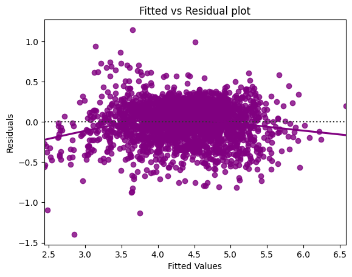

```python
# let's plot the fitted values vs residuals

sns.residplot(
    data=df_pred, x="Fitted Values", y="Residuals", color="purple", lowess=True
)
plt.xlabel("Fitted Values")
plt.ylabel("Residuals")
plt.title("Fitted vs Residual plot")
plt.show()
```

Test for normality

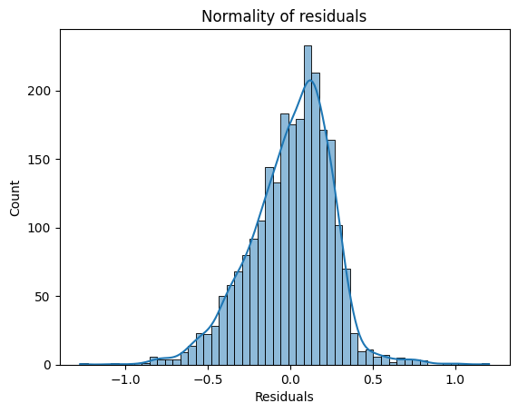

```python
sns.histplot(data=df_pred, x="Residuals", kde=True)
plt.title("Normality of residuals")
plt.show()
```

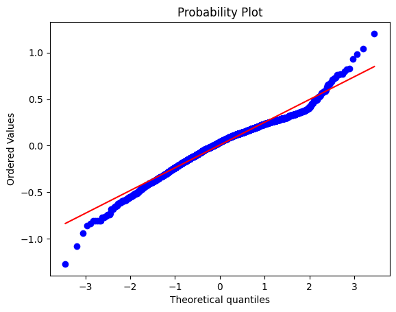

```python
import pylab
import scipy.stats as stats

stats.probplot(df_pred["Residuals"], dist="norm", plot=pylab)
plt.show()
```

```python
stats.shapiro(df_pred["Residuals"])
```

```
ShapiroResult(statistic=np.float64(0.9762227663128651), pvalue=np.float64(1.2005006266719988e-19))
```

Test for homoscedasticity

```python
import statsmodels.stats.api as sms
from statsmodels.compat import lzip

name = ["F statistic", "p-value"]
test = sms.het_goldfeldquandt(df_pred["Residuals"], df_pred)
lzip(name, test)
```

```
[('F statistic', np.float64(12.308502170962193)), ('p-value', np.float64(0.0))]
```

## Final Model

```python
olsmodel_final = sm.OLS(y_train, df_pred).fit()
olsmodel_final.summary()
```

OLS Regression Results

| Dep. Variable: | normalized_used_price | R-squared (uncentered): | 1.000 |
| --- | --- | --- | --- |
| Model: | OLS | Adj. R-squared (uncentered): | 1.000 |
| Method: | Least Squares | F-statistic: | 5.935e+33 |
| Date: | Mon, 05 May 2025 | Prob (F-statistic): | 0.00 |
| Time: | 07:08:57 | Log-Likelihood: | 78393. |
| No. Observations: | 2417 | AIC: | -1.568e+05 |
| Df Residuals: | 2415 | BIC: | -1.568e+05 |
| Df Model: | 2 |  |  |
| Covariance Type: | nonrobust |  |  |

|  | coef | std err | t | P>\|t\| | [0.025 | 0.975] |
| --- | --- | --- | --- | --- | --- | --- |
| Actual Values | 0.6667 | 5.44e-17 | 1.22e+16 | 0.000 | 0.667 | 0.667 |
| Fitted Values | 0.3333 | 5.47e-17 | 6.1e+15 | 0.000 | 0.333 | 0.333 |
| Residuals | 0.3333 | 1.09e-16 | 3.07e+15 | 0.000 | 0.333 | 0.333 |

| Omnibus: | 49.495 | Durbin-Watson: | 0.113 |
| --- | --- | --- | --- |
| Prob(Omnibus): | 0.000 | Jarque-Bera (JB): | 52.212 |
| Skew: | -0.360 | Prob(JB): | 4.60e-12 |
| Kurtosis: | 3.012 | Cond. No. | 1.72e+16 |

Notes:  
[1] R² is computed without centering (uncentered) since the model does not contain a constant.  
[2] Standard Errors assume that the covariance matrix of the errors is correctly specified.  
[3] The smallest eigenvalue is 3.17e-28. This might indicate that there are  
strong multicollinearity problems or that the design matrix is singular.

```python
print("Training Performance\n")
olsmodel_final_train_perf = model_performance_regression(olsmodel_final, df_pred, y_train)
olsmodel_final_train_perf
```

```
Training Performance
```

|  | RMSE | MAE | R-squared | Adj. R-squared | MAPE |
| --- | --- | --- | --- | --- | --- |
| 0 | 1.985354e-15 | 1.928766e-15 | 1.0 | 1.0 | 4.414047e-14 |

```python
print("Test Performance\n")
olsmodel_final_test_perf = model_performance_regression(olsmodel_final, df_pred, y_test)
olsmodel_final_test_perf
```

```
Test Performance
```

[output not shown]

## Actionable Insights and Recommendations

Devices with higher RAM and better cameras generally maintain a higher resale value.

Lesser-known or budget brands showed lower normalized used prices, even with higher specs.

3. Device Type & Battery Trade-Off Devices with batteries over 4500 mAh tend to be heavier, which could impact user comfort, especially for tablets.

There's a clear trade-off between battery capacity and device weight that brands may want to balance.